# Fun Temperature Plots in R

Ian Plummer

[Visit My Main Page](https://plummquat.github.io/IanPlummer/)

*Disclaimer: This page is going to be catered to folks that have somewhat of an understanding of R and how it works. That being said, all of this is going to be fairly easy to replicate and you only need to download R and RStudio and merely copy and paste these chunks of code into the terminal to do it yourself. I apologize for not making it easier to customize.*

Hello all! My initial inspiration for this particular data-vis stems from some really good work done by Brendan Wiltse of Paul Smith’s College. Ill link his work below.

> I hear talk about how nice the weather has been lately in the [#adirondacks](https://twitter.com/hashtag/adirondacks?src=hash&ref_src=twsrc%5Etfw). Here is a plot of the ADK3 climate data (pub linked below). Curves are GAMs, red is periods of sig ⬆️ in temp. Sept & Nov temps on the rise, Oct trending up as well. This is our climate future. 1/2 [pic.twitter.com/pR4iS3vQdM](https://t.co/pR4iS3vQdM)

> — Brendan Wiltse (@BrendanWiltse) [November 13, 2022](https://twitter.com/BrendanWiltse/status/1591785565799993344?ref_src=twsrc%5Etfw)

I thought this particular figure was a really neat way to show a time series, especially in consideration of monthly timescales. I wanted to find a way to go about replicating it on my own, mainly to challenge my coding skills. The following will allow you to follow along if you want to create this figure for an area near you. This can theoretically be done with any temperature data set from anywhere in the world. I decided to use a repository that I am familiar with but this code should be applicable to many other data sets with minor adjustments.

## Required Packages

For those not as familiar with R, the best way to download packages would be to go to the “Packages” tab in the right hand side of the RStudio window and type the names of these packages. For everyone else, it is likley that you have most of these packages downloaded already.

```r
library(tidyverse)
library(lubridate)
library(patchwork)
library(ggplot2)
library(GSODR) #This is the neat package to extract the data sets
```

## Extracting Data With GSODR

Im going to be taking data from the Global Surface Summary of the Day, which is curated by the National Centers for Environmental Information (NCEI). NCEI is a well trusted source of weather data and has stations all over the world. That being said, there are some quirks with this system that we are going to have to deal with in order to work with the data.

As mentioned, GSODR allows you to request data from stations all over the world, some of which have been recording for over 70 years. There are a number of ways to find station metadata, most of which are highlighted here but I will also briefly go over some of the more useful options.

If you simply want data from stations that are near you or a location of interest you can use the ‘nearest_stations’ command. This command allows you to plug in a Lat and Long for your location of interest and then a radius around said location. While this is a fairly easy command to follow, I find it better to actually explore the station locations graphically.

```r
load(system.file("extdata", "isd_history.rda", package = "GSODR"))
library(leaflet)

map_gsod <- isd_history  %>% leaflet() %>%
  addProviderTiles(providers$OpenStreetMap) %>%
  addMarkers(~ LON, ~ LAT, popup = ~ STNID, clusterOptions = T)

map_gsod
```

[interactive chart not shown]

This map allows you to zoom in on a given area and see all the stations that are in the GSODR system. I want to work with data from NYC and am particularly interested in Queens and Long Island. I have plenty of options so a flip of a coin leads me to LaGuardia Airport. No you will notice that many of these areas have 2 stations plotted in the same area. I am not sure as to the exact reason that GSODR does this, but longer data sets are split into two smaller data sets. This adds a small complication that is easy to deal with.

Before we download data, there is a slightly less clunky way to get station metadata, which many may find easier than the map. I also find that the map tends to be finicky and doesn’t display station titles 1/4th of the time. This alternative method involves requesting data for a specific country or state.

```r
my_stations<- isd_history %>%
  filter(ISO3C == "USA", STATE == "NY")
my_stations
```

| STNID | NAME | LAT | LON | CTRY | STATE | BEGIN | END | COUNTRY_NAME | ISO2C | ISO3C |
| --- | --- | --- | --- | --- | --- | --- | --- | --- | --- | --- |
| 720553-99999 | PORT AUTH DOWNTN MANHATTAN WALL ST HEL | 40.701 | -74.009 | US | NY | 20160720 | 20210116 | UNITED STATES | US | USA |
| 722098-64761 | EAST HAMPTON AIRPORT | 40.960 | -72.252 | US | NY | 20060101 | 20210117 | UNITED STATES | US | USA |
| 722098-99999 | EAST HAMPTON | 40.967 | -72.250 | US | NY | 20040713 | 20051231 | UNITED STATES | US | USA |
| 724098-99999 | AMBROSE / FT. TILDEN | 40.450 | -73.820 | US | NY | 19750915 | 19870430 | UNITED STATES | US | USA |
| 724988-94704 | DANSVILLE MUNICIPAL ARPT | 42.571 | -77.713 | US | NY | 20010102 | 20210117 | UNITED STATES | US | USA |
| 724988-99999 | DANSVILLE MUNI | 42.571 | -77.713 | US | NY | 20010811 | 20031231 | UNITED STATES | US | USA |
| 725010-99999 | UPTON | 40.850 | -72.850 | US | NY | 19990503 | 20050927 | UNITED STATES | US | USA |
| 725014-54780 | MONTAUK AIRPORT | 41.073 | -71.923 | US | NY | 20060101 | 20210117 | UNITED STATES | US | USA |
| 725014-99999 | MONTAUK | 41.083 | -71.917 | US | NY | 19990114 | 20051231 | UNITED STATES | US | USA |
| 725015-99999 | ORANGE CO | 41.510 | -74.260 | US | NY | 19990114 | 20051231 | UNITED STATES | US | USA |

[output cut: 113 more lines]

Were going to use the ‘get_GSOD’ command to extract data. You are going to have to play with the command a bit to figure out which station is the older/younger part of the record. I recommend trying to extract the whole record from one station and it will likely through an error that says something along the lines of “this station only has data from XXXX to YYYY”. That range will allow you to find the dates that can be extracted from both parts of the data set.

```r
met_df <- get_GSOD(years = 1973:2021, station = "725030-14732") #Command to get data from the younger portion of the LaGuardia record
met_df2 <- get_GSOD(years = 1948:1972, station = "999999-14732")#Command to get data from the older portion of the LaGuardia record
```

## Data Exploration

Now that we have thew data we may want to take an exploratory look to make sure everything looks good. For this im just going to plot the maximum and minimum temperatures for the whole record.

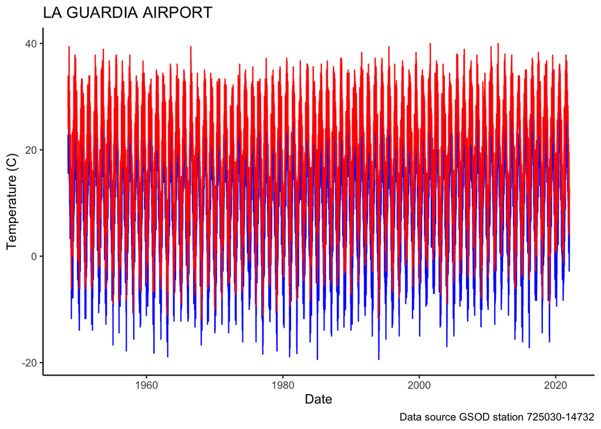

```r
queens_df %>%
  ggplot() +
  geom_line(aes(x = YEARMODA, y = MIN), color = "blue") +
  geom_line(aes(x = YEARMODA, y = MAX), color = "red") +
  labs(title = met_df$NAME[1],
       x = "Date",
       y = "Temperature (C)",
       caption = paste("Data source GSOD station", met_df$STNID[1])
       ) +
  theme_classic()
```

```r
qdf<- queens_df %>%
  group_by(YEAR, MONTH) %>%
  summarize(meanT= mean(TEMP), P = sum(PRCP))
qdf
```

| YEAR | MONTH | meanT | P |
| --- | --- | --- | --- |
| 1948 | 7 | 24.88064516 | NA |
| 1948 | 8 | 24.02258065 | NA |
| 1948 | 9 | 20.70000000 | NA |
| 1948 | 10 | 13.55806452 | NA |
| 1948 | 11 | 11.37333333 | NA |
| 1948 | 12 | 3.82258065 | NA |
| 1949 | 1 | 3.81612903 | NA |
| 1949 | 2 | 3.96785714 | NA |
| 1949 | 3 | 5.55483871 | NA |
| 1949 | 4 | 11.40000000 | NA |

[output cut: 872 more lines]

When looking at the data you may notice that there are a lot of ‘NA’ values for the precipitation column. This is because the station wasn’t recording accurate enough precipitation data until the 70s. This is a shame but there isn’t much we can do about it. Depending on the station you use you will find similar issues. NCEI will exclude data that is suspect or clearly not accurate (contrary to what climate change deniers will want you to believe), which may also explain some gaps.

Now it may be useful to compile the monthly means for each of these variables.

```r
qdfm<- queens_df %>%
  group_by(MONTH) %>%
  summarize(mean(TEMP))
qdfm
```

| MONTH | mean(TEMP) |
| --- | --- |
| 1 | 0.6157313 |
| 2 | 1.4729389 |
| 3 | 5.2140963 |
| 4 | 10.9865753 |
| 5 | 16.5631021 |
| 6 | 21.9444292 |
| 7 | 25.0115083 |
| 8 | 24.3100262 |
| 9 | 20.5721496 |
| 10 | 14.6982999 |

[output cut: 2 more lines]

Here comes some of the shortcomings to my coding skills. There is likely a better way to do this but I could only come up with the “brute force” method. The following code is going to create a column in this data set of the mean monthly values, which can probably be automated. I was getting frustrated doing that and ended up hard coding the values we calculated in the previous code into the data set. While certainly not the prettiest way to do it, this method was simple enough and worked as intended.

```r
qdf$monthly<-
  case_when(qdf$MONTH == 1 ~0.6157313,
            qdf$MONTH == 2 ~1.4729389,
            qdf$MONTH == 3 ~5.2140963,
            qdf$MONTH == 4 ~10.9865753,
            qdf$MONTH == 5 ~16.5631021,
            qdf$MONTH == 6 ~21.9444292,
            qdf$MONTH == 7 ~25.0115083,
            qdf$MONTH == 8 ~24.3100262,
            qdf$MONTH == 9 ~20.5721496,
            qdf$MONTH == 10 ~14.6982999,
            qdf$MONTH == 11 ~8.9614414,
            qdf$MONTH == 12 ~3.4076722)
```

Next we also want to give the actual names to the months in question, this will allow for the creation of better graphics later on.

```r
qdf$month_name<-
  case_when(qdf$MONTH == 1 ~"January",
            qdf$MONTH == 2 ~"February",
            qdf$MONTH == 3 ~"March",
            qdf$MONTH == 4 ~"April",
            qdf$MONTH == 5 ~"May",
            qdf$MONTH == 6 ~"June",
            qdf$MONTH == 7 ~"July",
            qdf$MONTH == 8 ~"August",
            qdf$MONTH == 9 ~"September",
            qdf$MONTH == 10 ~"October",
            qdf$MONTH == 11 ~"November",
            qdf$MONTH == 12 ~"December")
qdf$month_name<- factor(qdf$month_name, levels = c("January", "February", "March", "April", "May", "June", "July", "August", "September", "October", "November", "December"))
```

The next column is going to calculate the departure from monthly mean temperatures in any given month. In other words, the mean January temperatures for the whole data set will be subtracted from the January of any given year, lets say 2010 for arguments sake. The result is an anomaly or departure of 0.24 Celsius. The same is done for every month of every year.

```r
qdf$diff<- qdf$meanT - qdf$monthly
```

Now im going to replicate the monthly mean and anomaly code but do it for each year as a whole.

```r
q_yr<- queens_df %>%
  filter(YEAR > 1949) %>%
  group_by(YEAR) %>%
  summarize(Temp = mean(TEMP), P = sum(PRCP))

q_yr$mean<- mean(q_yr$Temp)
q_yr$diff<- q_yr$Temp - q_yr$mean
```

Once again, there is certainly a better way to go about doing this but I ended up hard coding the values from before into a new column in the data set.

```r
qdf$yearanom<- case_when(qdf$YEAR == 1950 ~-0.837022655,
                         qdf$YEAR == 1951 ~-0.067981559,
                         qdf$YEAR == 1952 ~ 0.343253563,
                         qdf$YEAR == 1953 ~ 0.967908852,
                         qdf$YEAR == 1954 ~-0.101406217,
                         qdf$YEAR == 1955 ~-0.097570600,
                        qdf$YEAR == 1956 ~-0.657566109,
                         qdf$YEAR == 1957 ~0.229826660,
                         qdf$YEAR == 1958 ~ -1.337296628,
                         qdf$YEAR == 1959 ~ 0.104895153,
                         qdf$YEAR == 1960 ~ -0.662757366,
                         qdf$YEAR == 1961 ~ -0.595104847,
                         qdf$YEAR == 1962 ~ -1.337844573,
                         qdf$YEAR == 1963 ~ -1.100310326,
                         qdf$YEAR == 1964 ~ -0.398003268,
                         qdf$YEAR == 1965 ~ -0.321311380,
                         qdf$YEAR == 1966 ~ -0.213461011,
                         qdf$YEAR == 1967 ~ -1.222776080,
                         qdf$YEAR == 1968 ~ -0.968221847,
                         qdf$YEAR == 1969 ~ -0.963871970,
                         qdf$YEAR == 1970 ~ -0.606611696,
                         qdf$YEAR == 1971 ~ -0.367707587,
                         qdf$YEAR == 1972 ~ -1.735161738,
                         qdf$YEAR == 1973 ~ 0.249552687,
                         qdf$YEAR == 1974 ~ -0.424967861,
                         qdf$YEAR == 1975 ~ -0.248255532,
                         qdf$YEAR == 1976 ~ -0.541719115,
                         qdf$YEAR == 1977 ~ -0.829899368,
                         qdf$YEAR == 1978 ~ -1.438940463,
                         qdf$YEAR == 1979 ~ -0.758940463,
                         qdf$YEAR == 1980 ~ -0.676418568,
                         qdf$YEAR == 1981 ~ -0.481680190,
                         qdf$YEAR == 1982 ~ -0.794830874,
                         qdf$YEAR == 1983 ~ -0.108803477,
                         qdf$YEAR == 1984 ~ -0.387620754,
                         qdf$YEAR == 1985 ~ -0.006885669,
                         qdf$YEAR == 1986 ~ -0.181954162,
                         qdf$YEAR == 1987 ~ -0.080310326,
                         qdf$YEAR == 1988 ~ -0.334888513,
                         qdf$YEAR == 1989 ~ -0.513461011,
                         qdf$YEAR == 1990 ~ 1.150922550,
                         qdf$YEAR == 1991 ~ 1.427086934,
                         qdf$YEAR == 1992 ~ -0.552648076,
                         qdf$YEAR == 1993 ~ 0.009004742,
                         qdf$YEAR == 1994 ~ 0.159689674,
                         qdf$YEAR == 1995 ~ 0.320511591,
                         qdf$YEAR ==1996 ~ -0.458385781,
                         qdf$YEAR == 1997 ~ -0.015378820,
                         qdf$YEAR == 1998 ~ 1.301881454,
                         qdf$YEAR == 1999 ~ 0.813662276,
                        qdf$YEAR == 2000 ~ -0.439533322,
                        qdf$YEAR == 2001 ~ 0.849278715,
                         qdf$YEAR == 2002 ~ 0.871196523,
                         qdf$YEAR == 2003 ~ -0.720310326,
                         qdf$YEAR == 2004 ~ -0.208112557,
                         qdf$YEAR == 2005 ~ 0.395580084,
                         qdf$YEAR == 2006 ~ 1.694758167,
                         qdf$YEAR == 2007 ~ 0.867908852,
                         qdf$YEAR == 2008 ~ 0.517843727,
                         qdf$YEAR == 2009 ~ -0.360584299,
                         qdf$YEAR == 2010 ~ 1.334210221,
                         qdf$YEAR == 2011 ~ 0.681059537,
                         qdf$YEAR == 2012 ~ 1.647351924,
                         qdf$YEAR == 2013 ~ 0.268730769,
                         qdf$YEAR == 2014 ~ -0.535378820,
                         qdf$YEAR == 2015 ~ 0.674484194,
                         qdf$YEAR == 2016 ~ 1.743526787,
                         qdf$YEAR == 2017 ~ 1.295032139,
                         qdf$YEAR == 2018 ~ 0.864621180,
                         qdf$YEAR == 2019 ~ 0.519415701,
                         qdf$YEAR == 2020 ~ 1.741614219,
                        qdf$YEAR == 2021 ~ 1.647086934)
```

Finally, we can combine everything into one big data set that I have ironically named qdf_slim…

```r
qdf_slim<- qdf %>%
  filter(YEAR >= 1950)
```

## Creating Graphics

The first figure I want to make is a simple line graph of the yearly mean temperatures for the whole record.

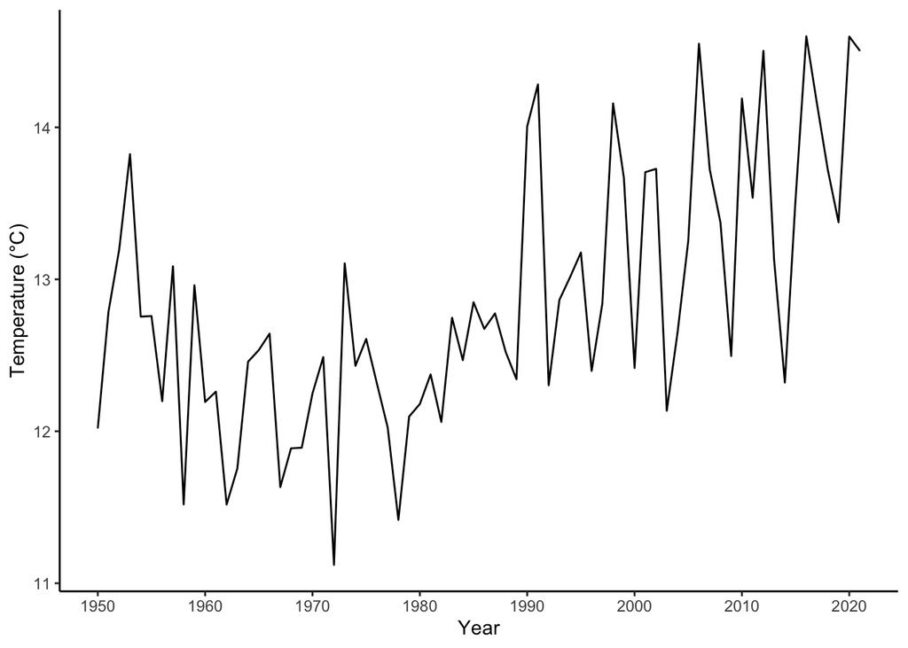

```r
ggplot(q_yr) + geom_line(aes(x = YEAR, y = Temp)) +
  theme_classic()+
  xlab("Year") +
  ylab("Temperature (°C)") +
  scale_x_continuous(breaks = c(1950, 1960, 1970, 1980, 1990, 2000, 2010, 2020))
```

Right, there is certainly a great deal of inter-annual variability but the trends are clear, average temperatures have been increasing over the last 70 years. There is room for more discussion about the drivers of this variability, most of which are natural climate variability (solar cycles, ENSO, NAO, volcanic eruptions, etc), but we would be here all day and I want to get to the neat graph.

```r
lg_main<- ggplot(qdf_slim)  + geom_point(aes( x = YEAR , y = meanT, color = diff), alpha = 0.9) +
  scale_color_gradient2(midpoint = 0, high = "red", mid = "gray", low = "blue") +
  geom_smooth(aes(x = YEAR, y = meanT), method = lm, color = "black") +
  facet_grid(. ~month_name) +
  theme_classic()+
  xlab("Year") +
  ylab("Temperature (°C)") +
  scale_x_continuous(breaks = c(1950, 1985, 2021)) +
  scale_y_continuous(breaks = c(-5, 0, 5, 10, 15, 20, 25, 30)) +
  theme(axis.text.x = element_text(angle = 70, vjust = 0.5, hjust=0.5)) +
  labs(colour="Temp Anom (°C)", title = "Monthly Mean Temperatures @ LaGuardia Airport 1950-2021", caption = "Source: GSOD Stations 725030-14732 & 999999-14732")
```

```r
lg_inset<- ggplot(q_yr) + geom_point(aes(x = YEAR, y = Temp)) +
  geom_smooth(aes(x = YEAR, y = Temp), method = lm, color = "black") +
  theme_classic()+
  xlab("Year") +
  ylab("Temperature (°C)") +
  scale_x_continuous(breaks = c(1950, 1960, 1970, 1980, 1990, 2000, 2010, 2020))
```

```r
#Use code below to save the file to your device, be sure to update the pathname to you desired location on your cdevice
#ggsave("pathname", width = 30, height = 15, units = "cm")
```

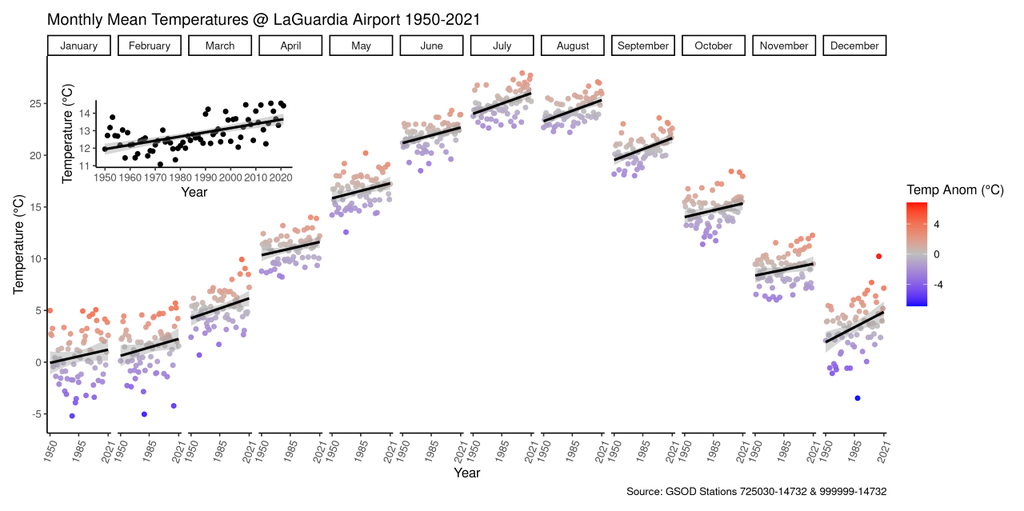

The Finishged Graphic in All Its Glory

### Breif Note on Precipitation

So the temperature graph came out quite nice, however, the precip data is much more sparse. While we can do the same kind of figure, it looks a bit, ehh.

```r
lg_main_p<- ggplot(qdf_slim)  + geom_point(aes( x = YEAR , y = P), alpha = 0.9) +
  geom_smooth(aes(x = YEAR, y = P), method = lm, color = "black") +
  facet_grid(. ~month_name) +
  theme_classic()+
  xlab("Year") +
  ylab("Precipitation (mm)") +
  scale_x_continuous(breaks = c(1950, 1985, 2021)) +
  scale_y_continuous(breaks = c(-5, 0, 5, 10, 15, 20, 25, 30)) +
  theme(axis.text.x = element_text(angle = 70, vjust = 0.5, hjust=0.5)) +
  labs(colour="Temp Anom (°C)", title = "Monthly Precipitation @ LaGuardia Airport 1950-2021", caption = "Source: GSOD Stations 725030-14732 & 999999-14732")
```

```r
lg_inset_p<- ggplot(q_yr) + geom_point(aes(x = YEAR, y = P)) +
  geom_smooth(aes(x = YEAR, y = P), method = lm, color = "black") +
  theme_classic()+
  xlab("Year") +
  ylab("Temperature (°C)") +
  scale_x_continuous(breaks = c(1950, 1960, 1970, 1980, 1990, 2000, 2010, 2020))
```

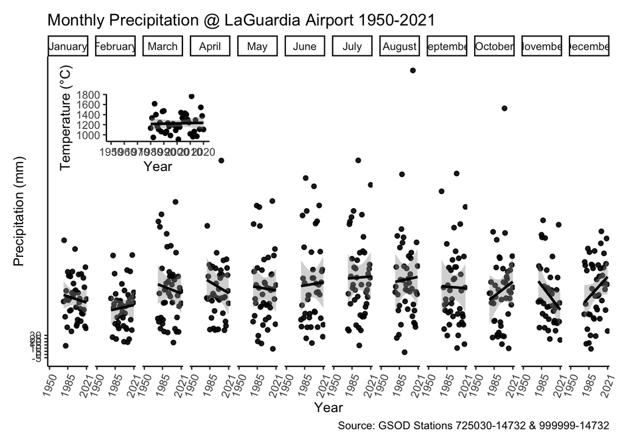

```r
lg_plot_p<- lg_main_p + inset_element(lg_inset_p, 0.01, 0.6, 0.3, 0.9)
lg_plot_p
```

By nature precipitation is more variable than temperature. This is made worse by the fact that the reliable precipitation data at this site is half the length of the temperature data. Most trends barely exist and if they do are not statistically significant. Brendan Wiltse had a bit more success with precipitation data in his longer data set. Recall that this graph can be made for any data set that you can find, whether its short, long, local, regional, or global. It is mainly good for visualizations of long term monthly trends in climate parameters, but nothing will replace regression analysis and traditional time series.